DS 6030 | Fall 2024 | University of Virginia

# Homework #1: Supervised Learning

Author

**Ainsley McLaughlin**

Published

September 10, 2024

# Required R packages and Directories

```r
library(tidyverse) # functions for data manipulation
```

# Problem 1: Evaluating a Regression Model

## a. Data generating functions

Create a set of functions to generate data from the following distributions:

$$\begin{align*}
X &\sim \mathcal{N}(0, 1) \\
Y &= -1 + .5X + .2X^2 + \epsilon \\
\epsilon &\sim \mathcal{N}(0,\, \sigma)
\end{align*}$$

**Solution**

```r
X_sim <- function(n) {
  rnorm(n, mean = 0, sd = 1)
}

# Function to generate Y given X_sim
Y_sim <- function(X, stdv) {
  n <- length(X)  # Get num samps from X
  epsilon <- rnorm(n, mean = 0, sd = stdv)  # noise term epsilon
  -1 + 0.5 * X + 0.2 * X^2 + epsilon  # put together
}
```

## b. Generate training data

Simulate $n=100$ realizations from these distributions using $\sigma=3$. Produce a scatterplot and draw the true regression line $f(x) = E[Y \mid X=x]$.

- Use `set.seed(611)` prior to generating the data.

**Solution**

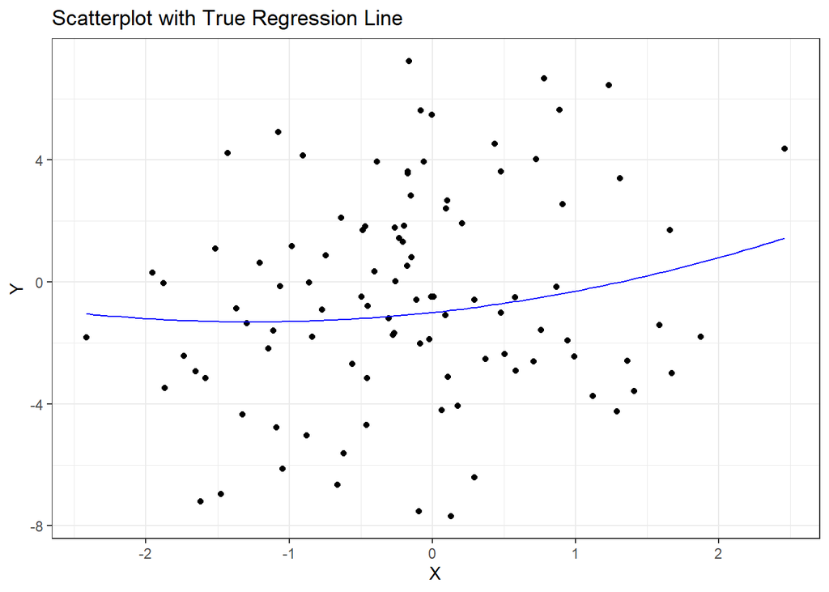

```r
# previous functions:

X_sim <- function(n) {
  rnorm(n, mean = 0, sd = 1)
}

# Function to generate Y given X_sim
Y_sim <- function(X, stdv) {
  n <- length(X)  # Get num samps from X
  epsilon <- rnorm(n, mean = 0, sd = stdv)  # noise term epsilon
  -1 + 0.5 * X + 0.2 * X^2 + epsilon  # put together
}
#-----------------------

#simulate realizations
set.seed(611)
# from x:
X <- X_sim(100)
# from y
Y <- Y_sim(X, 3)
# make df
sim_data=data.frame(X=X,Y=Y)
# ggplot
library(ggplot2)
# true reg function:
true_reg <- function(x) {
  -1 + 0.5 * x + 0.2 * x^2
}
#scatter plot
ggplot(sim_data, aes(x=X,y=Y)) +
geom_point()+
geom_function(fun = true_reg, color="blue")+
labs(title = "Scatterplot with True Regression Line",
       x = "X",
       y = "Y")
```

## c. Fit three models

Fit three polynomial regression models using least squares: linear, quadratic, and cubic. Produce another scatterplot, add the fitted lines and true population line $f(x)$ using different colors, and add a legend that maps the line color to a model.

- Note: The true model is quadratic, but we are also fitting linear (less complex) and cubic (more complex) models.

**Solution**

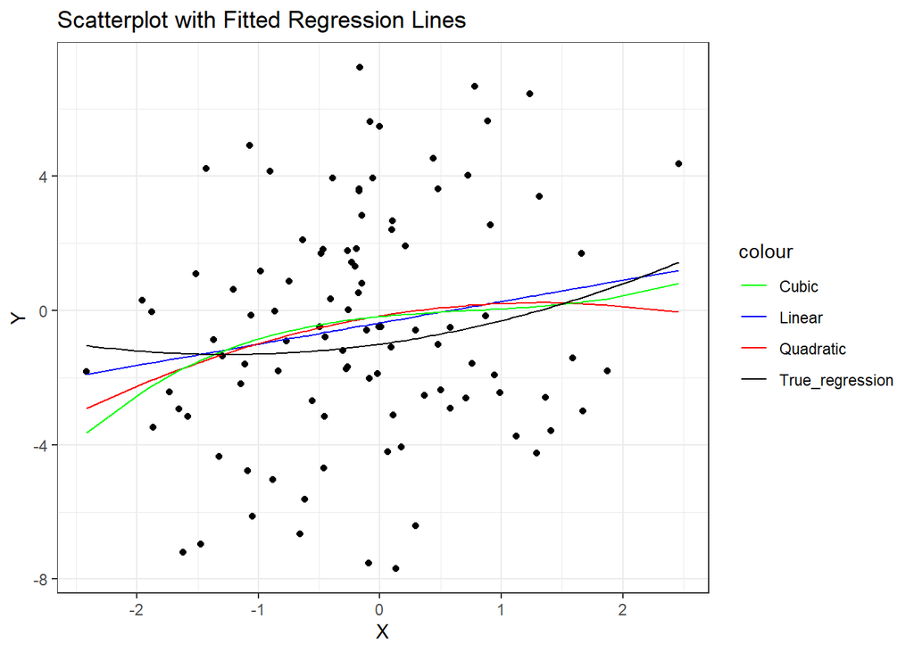

```r
#

#simulate realizations
set.seed(611)
# from x:
X <- X_sim(100)
# from y
Y <- Y_sim(X, 3)
# make df
sim_data=data.frame(X=X,Y=Y) # this is the training data with 100 observations
# ggplot
library(ggplot2)
# create the lines:

# true reg function:
true_reg <- function(x) {
  -1 + 0.5 * x + 0.2 * x^2}
lin_model <- lm(Y ~ poly(X, degree = 1), data = sim_data)
quad_model <- lm(Y ~ poly(X, degree = 2), data = sim_data)
cub_model <- lm(Y ~ poly(X, degree = 3), data = sim_data)


# Create predictions for plotting, add to the df that exists
sim_data$lin_pred <- predict(lin_model, newdata = sim_data)
sim_data$quad_pred <- predict(quad_model, newdata = sim_data)
sim_data$cub_pred <- predict(cub_model, newdata = sim_data)

# Scatter plot with fitted lines and true regression line
ggplot(sim_data, aes(x = X, y = Y), color=sim_data) +
  geom_point() +
  geom_line(aes(y = lin_pred, color="Linear")) +
  geom_line(aes(y = quad_pred, color="Quadratic")) +
  geom_line(aes(y = cub_pred, color="Cubic")) +
  geom_function(fun = true_reg, aes(color = "True_regression")) +
  labs(title = "Scatterplot with Fitted Regression Lines",
       x = "X",
       y = "Y")+
  scale_color_manual(values=c('Linear'='blue', 'Quadratic'='red','Cubic'='green','True_regression'='black'))
```

## d. Predictive performance

Generate a *test data* set of 10,000 observations from the same distributions. Use `set.seed(612)` prior to generating the test data.

- Calculate the estimated mean squared error (MSE) for each model.
- Are the results as expected?

**Solution**

```r
# ASK ABOUT THIS ONE
library(tidyverse)
#simulate test data
set.seed(612)
# from x:
X_test <- X_sim(10000)
# from y
Y_test <- Y_sim(X_test, 3)
# make df
test_data=tibble(X=X_test,Y=Y_test)

# models on the training data
lin_model <- lm(Y ~ poly(X, degree = 1), data = sim_data)
quad_model <- lm(Y ~ poly(X, degree = 2), data = sim_data)
cub_model <- lm(Y ~ poly(X, degree = 3), data = sim_data)

# predictions on test data
test_data$lin_pred <- predict(lin_model, newdata = test_data)
test_data$quad_pred <- predict(quad_model, newdata = test_data)
test_data$cub_pred <- predict(cub_model, newdata = test_data)

# calculate mse for each model: (note for next time the Metrics package has the mse function)
mse_linear <- mean((test_data$Y - test_data$lin_pred)^2)
mse_quadratic <- mean((test_data$Y - test_data$quad_pred)^2)
mse_cubic <- mean((test_data$Y - test_data$cub_pred)^2)
#print them
mse_linear
```

```
[1] 9.29
```

```r
mse_quadratic
```

```
[1] 9.58
```

```r
mse_cubic
```

```
[1] 9.65
```

Are the results as expected:

Above it was noted that “The true model is quadratic, but we are also fitting linear (less complex) and cubic (more complex) models.” Thus, we expect the quadratic model to have the lowest mse with cubic having the next lowest as it is closer to the true fit, although it might overfit. We expect the linear function to have the largest mse as it will underfit the data. This is not the case at all, so this result is very unexpected.

## e. Optimal performance

What is the best achievable MSE? That is, what is the MSE if the true $f(x)$ was used to evaluate the test set? How close does the best method come to achieving the optimum?

**Solution**

```r
library(Metrics)
#simulate test data
set.seed(612)
# from x:
X_test <- X_sim(10000)
# from y
Y_test <- Y_sim(X_test, 3)
# make df
#test_data=data.frame(X=X_test,Y=Y_test)
test_data=tibble(X=X_test, Y=Y_test)

# true regression function
true_reg <- function(x) {
  -1 + 0.5 * x + 0.2 * x^2
}

# true predictions for the test data
test_data$true_pred <- true_reg(test_data$X)

# best achievable MSE
best_mse <- mean((test_data$Y - test_data$true_pred)^2)
best_mse
```

```
[1] 8.97
```

```r
diff<-best_mse-mse_linear
diff
```

```
[1] -0.322
```

```r
# mse function:
#mse(test_data$Y, test_data$true_pred)
```

## f. Replication

The MSE scores obtained in part *d* came from one realization of training data. Here will we explore how much variation there is in the MSE scores by replicating the simulation many times.

- Re-run parts b. and c. (i.e., generate training data and fit models) 100 times.
  - Do not generate new testing data
  - Use `set.seed(613)` prior to running the simulation and do not set the seed in any other places.
- Calculate the test MSE for all simulations.
  - Use the same test data from part d. (This question is only about the variability that comes from the *training data*).
- Create kernel density or histogram plots of the resulting MSE values for each model.

**Solution**

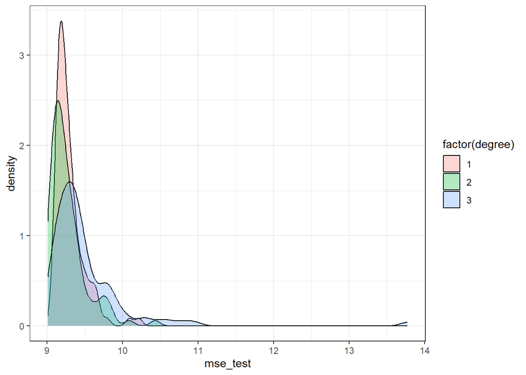

```r
library(tidyverse)

#Define functions for simulation and model evaluation
X_sim <- function(n) {
  rnorm(n, mean = 0, sd = 1)
}

Y_sim <- function(X, stdv) {
  n <- length(X)  # Get num samps from X
  epsilon <- rnorm(n, mean = 0, sd = stdv)  # noise term epsilon
  -1 + 0.5 * X + 0.2 * X^2 + epsilon  # put together
}

true_reg <- function(x) {
  -1 + 0.5 * x + 0.2 * x^2
}

# evaluate the models
poly_eval <- function(deg, data_train, data_test) {
  if (deg == 0) {
    m <- lm(Y ~ 1, data = data_train)  # intercept only model
  } else {
    m <- lm(Y ~ poly(X, degree = deg), data = data_train)  # polynomial
  }
  # Calculate test MSE
  yhat <- predict(m, data_test)  # predictions at test X's
  mse_test <- mean((data_test$Y - yhat)^2)  # test MSE
  # Output a data frame of relevant info
  tibble(degree = deg, mse_test = mse_test)
}

set.seed(613)

# Generate test data (same for all simulations)
X_test <- X_sim(10000)
Y_test <- Y_sim(X_test, 3)
test_data <- data.frame(X = X_test, Y = Y_test)

# data frame to store MSE's
results <- data.frame()

#do it 100 times
for (i in 1:100) {
  # training data
  X_train <- X_sim(100)
  Y_train <- Y_sim(X_train, 3)
  train_data <- data.frame(X = X_train, Y = Y_train)

  # fit models, calc MSE
  lin_mse <- poly_eval(deg = 1, data_train = train_data, data_test = test_data)
  quad_mse <- poly_eval(deg = 2, data_train = train_data, data_test = test_data)
  cub_mse <- poly_eval(deg = 3, data_train = train_data, data_test = test_data)

  # results
  results <- bind_rows(results, lin_mse, quad_mse, cub_mse)
}

# kernel density of MSE
ggplot(results, aes(x = mse_test, fill = factor(degree))) +
  geom_density(alpha=0.3)
```

## g. Best model

Show a count of how many times each model was the best. That is, out of the 100 simulations, count how many times each model had the lowest MSE.

**Solution**

```r
# A DIFFERENCE HERE

# Define functions for simulation and model evaluation
X_sim <- function(n) {
  rnorm(n, mean = 0, sd = 1)
}

Y_sim <- function(X, stdv) {
  n <- length(X)  # Get num samps from X
  epsilon <- rnorm(n, mean = 0, sd = stdv)  # noise term epsilon
  -1 + 0.5 * X + 0.2 * X^2 + epsilon  # put together
}

true_reg <- function(x) {
  -1 + 0.5 * x + 0.2 * x^2
}

# Function to fit, predict, and evaluate a polynomial regression model
poly_eval <- function(deg, data_train, data_test) {
  if (deg == 0) {
    m <- lm(Y ~ 1, data = data_train)  # intercept only model
  } else {
    m <- lm(Y ~ poly(X, degree = deg), data = data_train)  # polynomial
  }
  # Calculate test MSE
  yhat <- predict(m, data_test)  # predictions at test X's
  mse_test <- mean((data_test$Y - yhat)^2)  # test MSE
  # Output a data frame of relevant info
  tibble(degree = deg, mse_test = mse_test)
}

# Set seed for reproducibility
set.seed(613)

# Generate test data (same for all simulations)
X_test <- X_sim(10000)
Y_test <- Y_sim(X_test, 3)
test_data <- data.frame(X = X_test, Y = Y_test)

# Initialize a data frame to store MSE results and a vector to count best models
results <- data.frame()
best_model_count <- tibble(degree = c(1, 2, 3), count = 0)

# Run the simulation 100 times
for (i in 1:100) {
  # Generate training data
  X_train <- X_sim(100)
  Y_train <- Y_sim(X_train, 3)
  train_data <- data.frame(X = X_train, Y = Y_train)

  # Fit models and calculate MSE
  lin_mse <- poly_eval(deg = 1, data_train = train_data, data_test = test_data)
  quad_mse <- poly_eval(deg = 2, data_train = train_data, data_test = test_data)
  cub_mse <- poly_eval(deg = 3, data_train = train_data, data_test = test_data)

  # Combine results
  simulation_results <- bind_rows(lin_mse, quad_mse, cub_mse)
  results <- bind_rows(results, simulation_results)

  # Identify the best model in this simulation
  best_model <- simulation_results %>%
    filter(mse_test == min(mse_test)) %>%
    pull(degree)

  # Update the count of best models
  best_model_count <- best_model_count %>%
    mutate(count = ifelse(degree %in% best_model, count + 1, count))
}

# Print the count of how many times each model was the best
best_model_count
```

```
# A tibble: 3 × 2
  degree count
   <dbl> <dbl>
1      1    28
2      2    64
3      3     8
```

## h. Function to implement simulation

Write a function that implements the simulation in part *f*. The function should have arguments for i) the size of the training data $n$, ii) the standard deviation of the random error $\sigma$, and iii) the test data. Use the same `set.seed(613)`.

**Solution**

```r
library(tidyverse)

# Define the simulation function
run_simulation <- function(n, sigma, test_data) {
  set.seed(613)

  # Define functions for simulation
  X_sim <- function(n) {
    rnorm(n, mean = 0, sd = 1)
  }

  Y_sim <- function(X, stdv) {
    n <- length(X)  # Get num samps from X
    epsilon <- rnorm(n, mean = 0, sd = stdv)  # noise term epsilon
    -1 + 0.5 * X + 0.2 * X^2 + epsilon  # put together
  }

  poly_eval <- function(deg, data_train, data_test) {
    if (deg == 0) {
      m <- lm(Y ~ 1, data = data_train)  # intercept only model
    } else {
      m <- lm(Y ~ poly(X, degree = deg), data = data_train)  # polynomial
    }
    # Calculate test MSE
    yhat <- predict(m, data_test)  # predictions at test X's
    mse_test <- mean((data_test$Y - yhat)^2)  # test MSE
    # Output a data frame of relevant info
    tibble(degree = deg, mse_test = mse_test)
  }

  # Initialize a data frame to store MSE results and a vector to count best models
  results <- data.frame()
  best_model_count <- tibble(degree = c(1, 2, 3), count = 0)

  # Run the simulation 100 times
  for (i in 1:100) {
    # Generate training data
    X_train <- X_sim(n)
    Y_train <- Y_sim(X_train, sigma)
    train_data <- data.frame(X = X_train, Y = Y_train)

    # Fit models and calculate MSE
    lin_mse <- poly_eval(deg = 1, data_train = train_data, data_test = test_data)
    quad_mse <- poly_eval(deg = 2, data_train = train_data, data_test = test_data)
    cub_mse <- poly_eval(deg = 3, data_train = train_data, data_test = test_data)

    # Combine results
    simulation_results <- bind_rows(lin_mse, quad_mse, cub_mse)
    results <- bind_rows(results, simulation_results)

    # Identify the best model in this simulation
    best_model <- simulation_results %>%
      filter(mse_test == min(mse_test)) %>%
      pull(degree)

    # Update the count of best models
    best_model_count <- best_model_count %>%
      mutate(count = ifelse(degree %in% best_model, count + 1, count))
  }

  # Return results and best model counts
  print(list(results = results, best_model_count = best_model_count))
}
```

## i. Performance when $\sigma=2$

Use your function to repeat the simulation in part *f*, but use $\sigma=2$. Report the number of times each model was best (you do not need to produce any plots).

- Be sure to generate new test data with ($n = 10000$, $\sigma = 2$, using `seed = 612`).

**Solution**

```r
# SAME
# Define the simulation function
run_simulation <- function(n, sigma, test_data) {
  set.seed(613)

  # Define functions for simulation
  X_sim <- function(n) {
    rnorm(n, mean = 0, sd = 1)
  }

  Y_sim <- function(X, stdv) {
    n <- length(X)  # Get num samps from X
    epsilon <- rnorm(n, mean = 0, sd = stdv)  # noise term epsilon
    -1 + 0.5 * X + 0.2 * X^2 + epsilon  # put together
  }

  poly_eval <- function(deg, data_train, data_test) {
    if (deg == 0) {
      m <- lm(Y ~ 1, data = data_train)  # intercept only model
    } else {
      m <- lm(Y ~ poly(X, degree = deg), data = data_train)  # polynomial
    }
    # Calculate test MSE
    yhat <- predict(m, data_test)  # predictions at test X's
    mse_test <- mean((data_test$Y - yhat)^2)  # test MSE
    # Output a data frame of relevant info
    tibble(degree = deg, mse_test = mse_test)
  }

  # Initialize a data frame to store MSE results and a vector to count best models
  results <- data.frame()
  best_model_count <- tibble(degree = c(1, 2, 3), count = 0)

  # Run the simulation 100 times
  for (i in 1:100) {
    # Generate training data
    X_train <- X_sim(n)
    Y_train <- Y_sim(X_train, sigma)
    train_data <- data.frame(X = X_train, Y = Y_train)

    # Fit models and calculate MSE
    lin_mse <- poly_eval(deg = 1, data_train = train_data, data_test = test_data)
    quad_mse <- poly_eval(deg = 2, data_train = train_data, data_test = test_data)
    cub_mse <- poly_eval(deg = 3, data_train = train_data, data_test = test_data)

    # Combine results
    simulation_results <- bind_rows(lin_mse, quad_mse, cub_mse)
    results <- bind_rows(results, simulation_results)

    # Identify the best model in this simulation
    best_model <- simulation_results %>%
      filter(mse_test == min(mse_test)) %>%
      pull(degree)

    # Update the count of best models
    best_model_count <- best_model_count %>%
      mutate(count = ifelse(degree %in% best_model, count + 1, count))
  }

  # Return results and best model counts
  list(results = results, best_model_count = best_model_count)
}

# Set seed for generating test data
set.seed(612)

# Generate new test data with sigma = 2
X_test <- X_sim(10000)
Y_test <- Y_sim(X_test, 2)
test_data <- data.frame(X = X_test, Y = Y_test)

# Run the simulation function with sigma = 2
simulation_results <- run_simulation(n = 100, sigma = 2, test_data = test_data)

# Print the count of how many times each model was the best
print(simulation_results$best_model_count)
```

```
# A tibble: 3 × 2
  degree count
   <dbl> <dbl>
1      1    19
2      2    71
3      3    10
```

## j. Performance when $\sigma=4$ and $n=300$

Repeat *i*, but now use $\sigma=4$ and $n=300$.

- Be sure to generate new test data with ($n = 10000$, $\sigma = 4$, using `seed = 612`).

**Solution**

```r
# Define the simulation function
run_simulation <- function(n, sigma, test_data) {
  set.seed(613)

  # Define functions for simulation
  X_sim <- function(n) {
    rnorm(n, mean = 0, sd = 1)
  }

  Y_sim <- function(X, stdv) {
    n <- length(X)  # Get num samps from X
    epsilon <- rnorm(n, mean = 0, sd = stdv)  # noise term epsilon
    -1 + 0.5 * X + 0.2 * X^2 + epsilon  # put together
  }

  poly_eval <- function(deg, data_train, data_test) {
    if (deg == 0) {
      m <- lm(Y ~ 1, data = data_train)  # intercept only model
    } else {
      m <- lm(Y ~ poly(X, degree = deg), data = data_train)  # polynomial
    }
    # Calculate test MSE
    yhat <- predict(m, data_test)  # predictions at test X's
    mse_test <- mean((data_test$Y - yhat)^2)  # test MSE
    # Output a data frame of relevant info
    tibble(degree = deg, mse_test = mse_test)
  }

  # Initialize a data frame to store MSE results and a vector to count best models
  results <- data.frame()
  best_model_count <- tibble(degree = c(1, 2, 3), count = 0)

  # Run the simulation 100 times
  for (i in 1:100) {
    # Generate training data
    X_train <- X_sim(n)
    Y_train <- Y_sim(X_train, sigma)
    train_data <- data.frame(X = X_train, Y = Y_train)

    # Fit models and calculate MSE
    lin_mse <- poly_eval(deg = 1, data_train = train_data, data_test = test_data)
    quad_mse <- poly_eval(deg = 2, data_train = train_data, data_test = test_data)
    cub_mse <- poly_eval(deg = 3, data_train = train_data, data_test = test_data)

    # Combine results
    simulation_results <- bind_rows(lin_mse, quad_mse, cub_mse)
    results <- bind_rows(results, simulation_results)

    # Identify the best model in this simulation
    best_model <- simulation_results %>%
      filter(mse_test == min(mse_test)) %>%
      pull(degree)

    # Update the count of best models
    best_model_count <- best_model_count %>%
      mutate(count = ifelse(degree %in% best_model, count + 1, count))
  }

  # Return results and best model counts
  list(results = results, best_model_count = best_model_count)
}

# Set seed for generating test data
set.seed(612)

# Generate new test data with sigma = 4
X_test <- X_sim(10000)
Y_test <- Y_sim(X_test, 4)
test_data <- data.frame(X = X_test, Y = Y_test)

# Run the simulation function with sigma = 2
simulation_results <- run_simulation(n = 300, sigma = 4, test_data = test_data)

# Print the count of how many times each model was the best
print(simulation_results$best_model_count)
```

```
# A tibble: 3 × 2
  degree count
   <dbl> <dbl>
1      1     8
2      2    80
3      3    12
```

## k. Understanding

Describe the effects $\sigma$ and $n$ has on selection of the best model? Why is the *true* model form (i.e., quadratic) not always the *best* model to use when prediction is the goal?

**Solution**

Simpler models (linear) might have higher bias but lower variance, making them better with more error or less data. This can lead to better performance on test data.

More complex models might have lower bias and so fit the training data better, but have high variance, especially with less data or more error. This can result in bad generalization.